# AWS Sentiment & Review Date/Time Part 1

Eugenie

07/08/2019

# 1 Load Source File

Load data.

```r
########################## load library ############################
## for data manipulation
library(plyr)
library(dplyr)
library(tidyr)
library(purrr)
library(readr)
library(stringr)
library(reshape)
```

```r
## for plotting
library(ggplot2)
library(ggmosaic)
library(plotly)
library(ggpubr)
## for modelling
library(plm)
library(mgcv)
library(GoodmanKruskal)

## for sentiment analysis
library(tidytext)
library(textdata)
library(textclean)
library(gutenbergr)
library(scales)
library(tm)
library(sentimentr)
## read .xlsx files
library(readxl)

## time/date
library(chron)
library(lubridate)
## for tables
library(stargazer)
reviews3.csv <- read.csv("~/Dropbox/Eugenie/data/processed/processed-reviews3.csv")
```

# 2 Data Processing

Get selected columns for further analysis.

```r
reviews.product <- reviews3.csv[,c('recid','item_id','incentivized','product_cat','rating','word_count','helpful_yes','date','year','month','weeks','positive','neutral')]

names(reviews.product) <- c('recid','item_id','incentivized','product_cat','rating','word_count','helpful_yes','date','year','month','week','positive','neutral')
```

```r
#reviews2.temp <- reviews2.temp[as.numeric(as.character(reviews2.temp$year))>2013,]
```

```r
## turn factor to date variable
reviews.product$date <- as.Date(reviews.product$date, "%Y-%m-%d")
#reviews2.temp <- reviews2.temp[reviews2.temp$date < '2019-09-16',]
```

Drop records with no product category.

```r
reviews.product <- reviews.product[reviews.product$product_cat != 'none',]
```

# 3 Time Data vs. Positive Sentiment Probability

## 3.1 Data processing

Split data on date without splitting incentivized vs. non-incentivized reviews after 2016-10-03.

Compute positive sentiment stats without splitting incentivized vs. non-incentivized reviews after 2016-10-03.

## 3.2 Plot mean positive sentiment probability over time by product_cat without splitting incentivized vs. non-incentivized reviews after 2016-10-03

### 3.2.1 Positive sentiment probability average by day

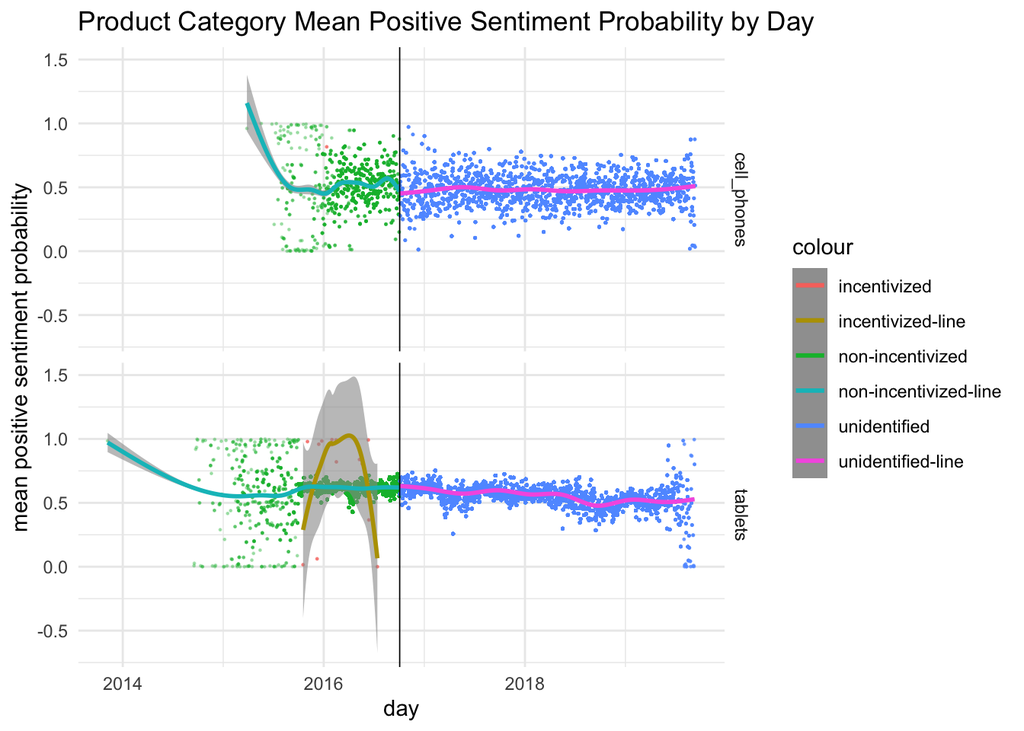

Observed that prior to 2016-10-03, the day average of incentivized reviews is generally higher and has a greater variation than non-incentivized reviews.

### 3.2.2 Positive sentiment probability averaged by week

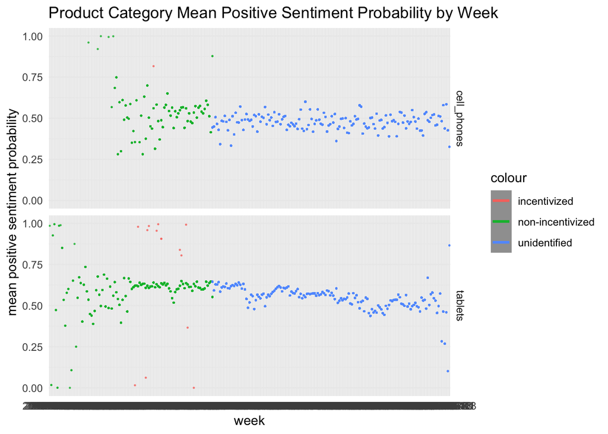

# 4 Time Data vs. Neutral Sentiment Probability

## 4.1 Data processing

Compute neutral sentiment stats without splitting incentivized vs. non-incentivized reviews after 2016-10-03.

## 4.2 Plot mean neutral sentiment probability over time by product_cat without splitting incentivized vs. non-incentivized reviews after 2016-10-03

### 4.2.1 Neutral sentiment probability average by day

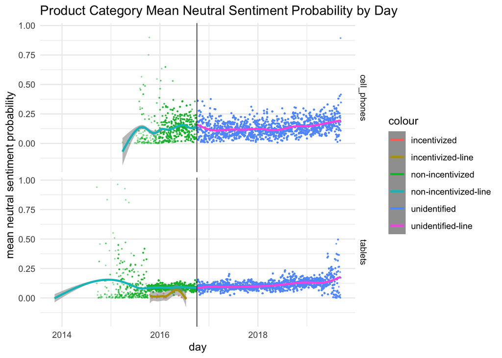

### 4.2.2 Neutral sentiment probability averaged by week

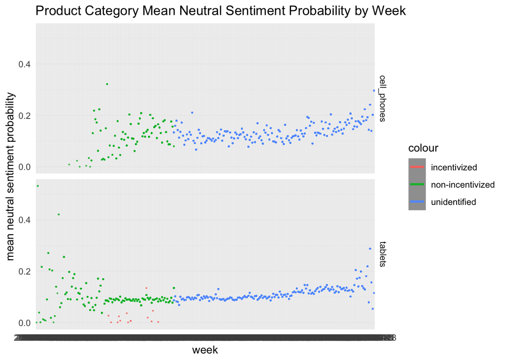